# Forecasting Urban Development in Denver, 2020

Attn: Denver Regional Council of Governments (DRCOG)

Justine Kone & Evan Cernea

May 4, 2018

### Introduction

The DRCOG has requested forecasts of Greater Denver’s urban development in 2020 based on:

1. Demand-side change
2. Supply-side change

To produce these forecasts, we first mined the available data to determine which factors were likely to be good predictors, and used the results to engineer additional variables that would predict well. Then, we created a model that predicts change in development from 2001 to 2011. After validating this model using the actual change in development during that time period, we used the model to predict development in 2020.

The final section of this document outlines the adjusted predictions based on the anticipated demand-side and supply-side changes, and provides recommendations for responsibly allocating this new development.

### Exploratory Analysis & Feature Engineering

Regardless of municipality size or location, future development is largely a function of proximity to currently developed areas. Figure 1 shows developed areas in 2001.

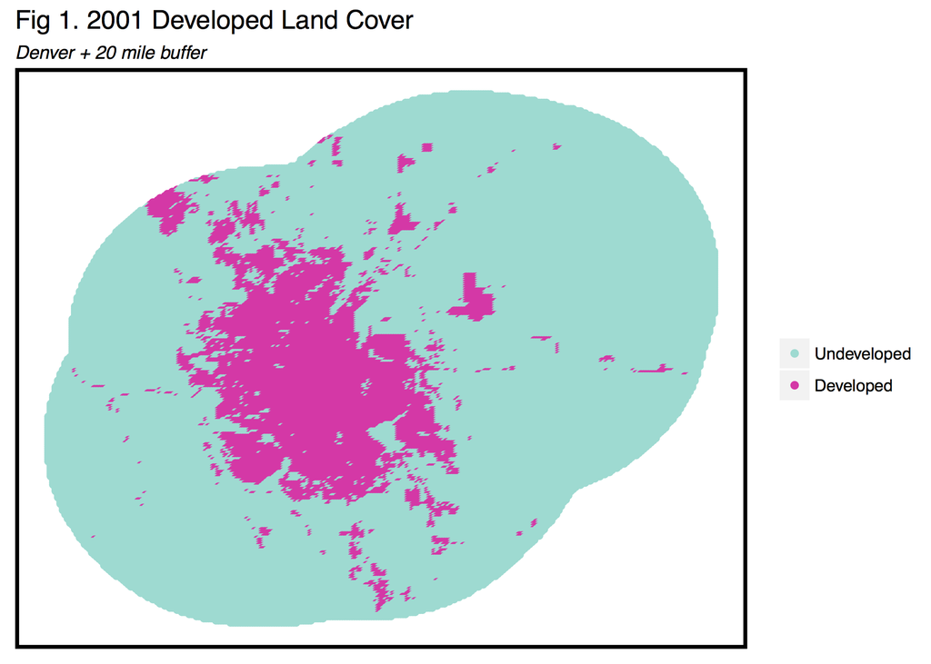

In addition to looking at the change in development, we focused on land use, population, and proximity to transportation. Figure 2 shows that 2010 population, 2010 population density, and distance to the lightrail are likely correlated with change in development because of the variation between areas with new development and areas without.

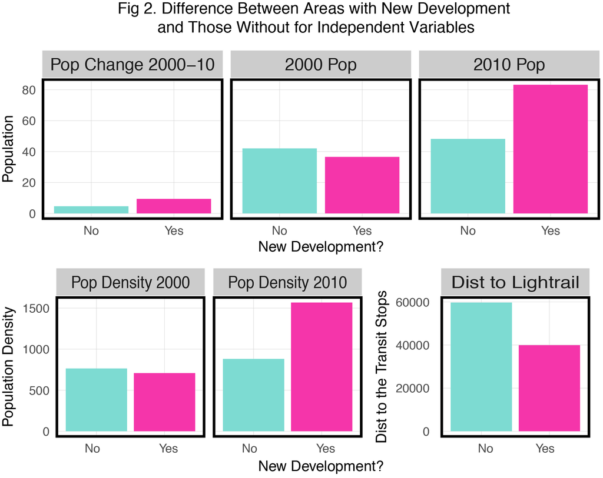

Based on the results of our preliminary analysis, we engineered additional features likely to improve the accuracy of our model. We calculated spatial lags for population (Figure 3), development, and development change to account for spatial differences. In particular, we wanted to capture the phenomenon that areas are more likely to be similar to neighboring areas than they are to distant ones. Similarly, we created a binary proximity variable called `touching` to describe whether a cell is directly next to development.

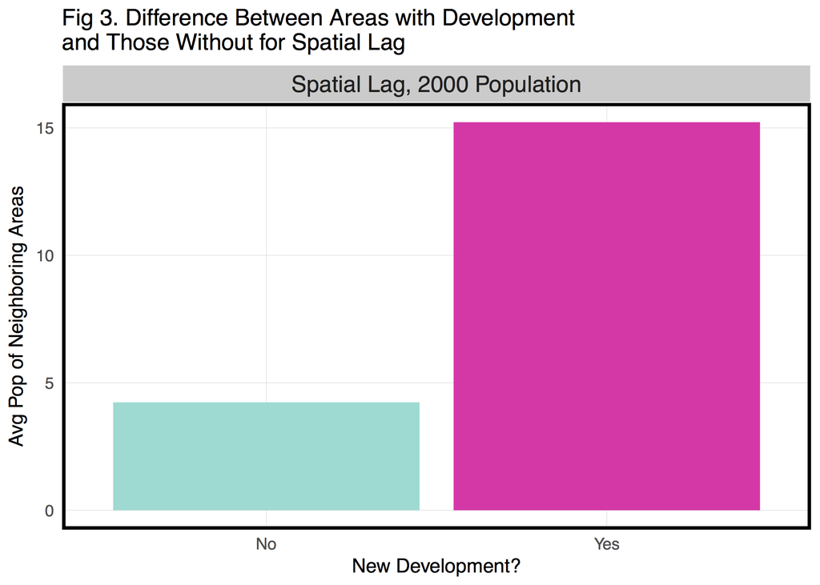

After building our initial models, we noticed that the Denver International Airport is classified as development, misleading the models into predicting new development next to the airport. As the DRCOG will likely agree, the area adjacent to Denver’s airport is unlikely to be on any developer’s shortlist for a new site. To remedy this inaccuracy, we created a fixed effect for whether or not an area was located in the airport.

### Results & Validation

```r
summary(model4)
```

```
##
## Call:
## glm(formula = change0111 ~ popChange + lc2001 + touching + transdist +
##     devdist + airport + roaddist + weightedSLPop2010 + weightedSLPop2000 +
##     pctPopChange, family = binomial(link = "logit"), data = datTrain)
##
## Deviance Residuals:
##     Min       1Q   Median       3Q      Max
## -2.9708  -0.1968  -0.1249  -0.0703   3.7886
##
## Coefficients:
##                     Estimate Std. Error z value Pr(>|z|)
## (Intercept)       -1.731e+01  2.749e+02  -0.063  0.94980
## popChange          9.664e-03  1.162e-03   8.315  < 2e-16 ***
## lc20012            1.071e+01  2.749e+02   0.039  0.96893
## lc20013            1.538e+01  2.749e+02   0.056  0.95537
## lc20014            1.247e+01  2.749e+02   0.045  0.96382
## lc20015            1.377e+01  2.749e+02   0.050  0.96005
## lc20016            1.474e+01  2.749e+02   0.054  0.95723
## lc20017            1.479e+01  2.749e+02   0.054  0.95708
## lc20018            1.224e+01  2.749e+02   0.045  0.96449
## touching1          9.979e-01  1.158e-01   8.615  < 2e-16 ***
## transdist         -1.848e-05  1.893e-06  -9.764  < 2e-16 ***
## devdist           -1.467e-03  2.510e-04  -5.842 5.15e-09 ***
## airport1          -2.565e+00  6.494e-01  -3.950 7.82e-05 ***
## roaddist           3.360e+00  1.098e+00   3.061  0.00220 **
## weightedSLPop2010  4.793e-03  1.098e-03   4.366 1.27e-05 ***
## weightedSLPop2000 -3.450e-03  1.266e-03  -2.724  0.00644 **
## pctPopChange       3.157e-05  1.414e-05   2.233  0.02554 *
## ---
## Signif. codes:  0 '***' 0.001 '**' 0.01 '*' 0.05 '.' 0.1 ' ' 1
##
## (Dispersion parameter for binomial family taken to be 1)
##
##     Null deviance: 5517.5  on 25767  degrees of freedom
## Residual deviance: 4183.6  on 25751  degrees of freedom
## AIC: 4217.6
##
## Number of Fisher Scoring iterations: 16
```

```r
pR2(model4)
```

```
##           llh       llhNull            G2      McFadden          r2ML
## -2.091789e+03 -2.758764e+03  1.333950e+03  2.417659e-01  5.045057e-02
##          r2CU
##  2.617395e-01
```

Although not all the variables were significant, they generated the ROC curve shown in Figure 4, with an area under the curve of .87. The area under the curve indicates the strength of the model’s ability to discriminate between where gridcells would and would not be developed. An area of .87 indicates a very good ability to discrimate, a 75 percent improvement over a coin flip.

#### Figure 4

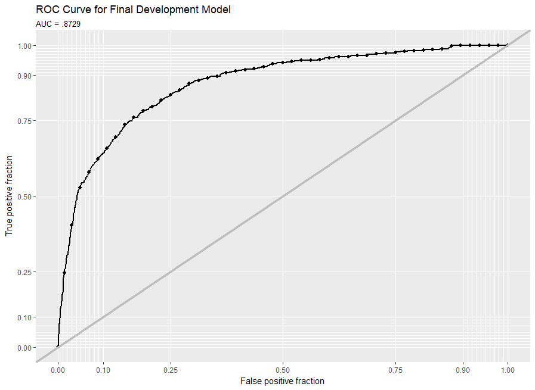

We wanted to ensure that the success of this model was not a fluke based on the training data. To ensure that our model held its validity across different training dataset combinations, we used the cross-validation features. Using the `resample` dataframe, we looked at the distribution of accuracies generated when the training data was restructured in 100 different combinations. Figure 5 below shows that the accuracy of the model clustered between .95 and 1, meaning that it was generalizable across different data sets and would be considered valid.

#### Figure 5

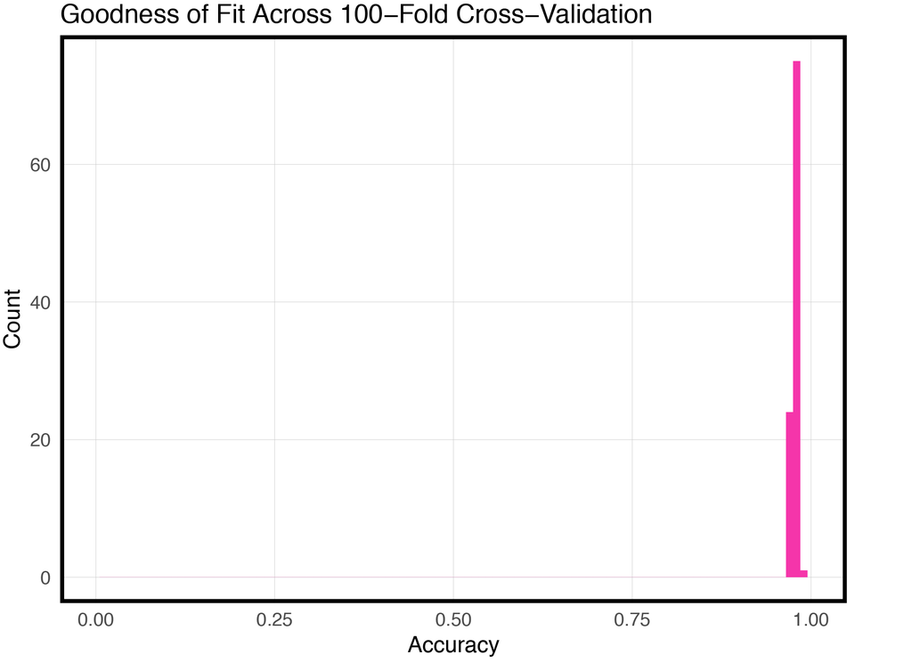

We also wanted to see if the model held up when certain census tracts were withheld from the training data. We filtered out all the census tracts where no development change occured. We then ran a spatial cross validation function to assess how well the model performed across different census tracts. The metric used was area under the curve, to determine how well the model discriminated for new development in each tract. The model used in the spatial cross validation function had to leave out the airport variable because it was not represented in every factor level. We believe that this would not seriously impact the quality of the model, although it is a known limitation.

As seen in Figure 6 below, there was not much consistency across different census tracts. This is perhaps due to the sheer size of the Denver metropolitan area and the variety of landcover types that are represented in the different census tracts. There may have also been features that we excluded from this model that would have created a more consistent spatial cross validation, such as slope and elevation, as the western edge of the Denver metropolitan area is much hillier and steeper than the plains in the East.

#### Figure 6

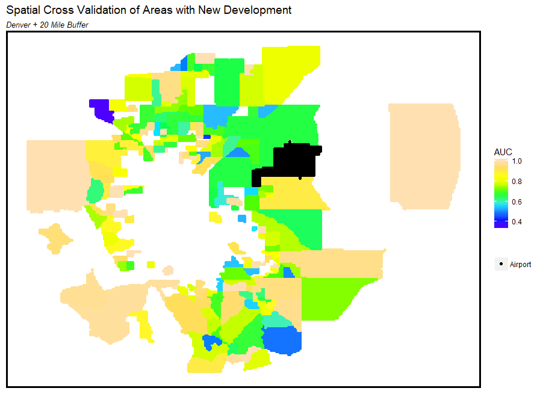

Once we generated this model with its high AUC and made sure it was applicable across multiple datasets, we wanted to figure out what the best predicted probability cutoff would be to maximize for both sensitivity and specificty. Sensitivity is the ability of the model to determine where change in developed landcover actually occured, and specificty is the ability of the model to determine where change in developed landcover actually did not occur. We wanted to choose a cutoff point where both metrics were relatively high. We prioritized specificty over sensitivity because we believed that we were already overpredicting future development, and chose a cutoff of .1 because it predicted fewer new development points. In Figure 7, the tradeoff between sensitivity and specificty at different cutoffs is shown

#### Figure 7

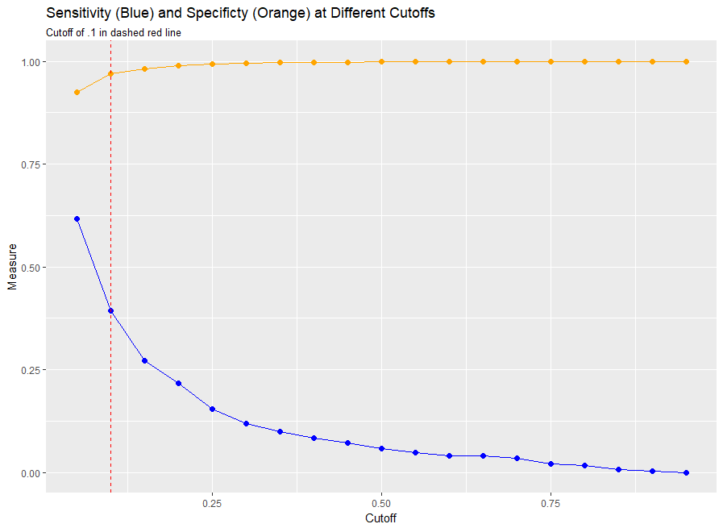

After choosing this cutoff, we wanted to map where the model predicted new development. That map is included in Figure 8 below:

#### Figure 8

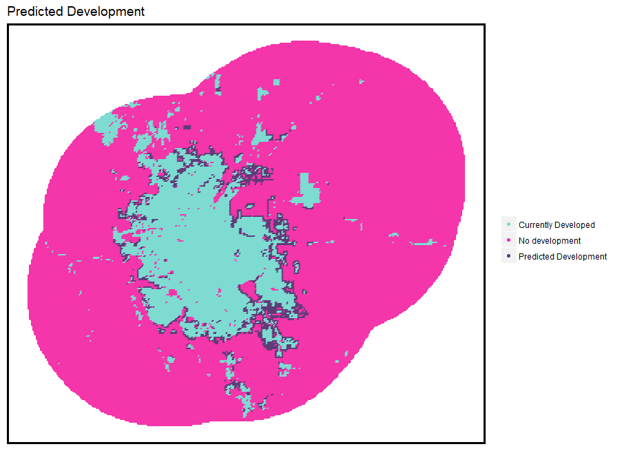

It was also important for us to see where we correctly and incorrectly made our predictions. These results can be seen in Figure 9 below:

#### Figure 9

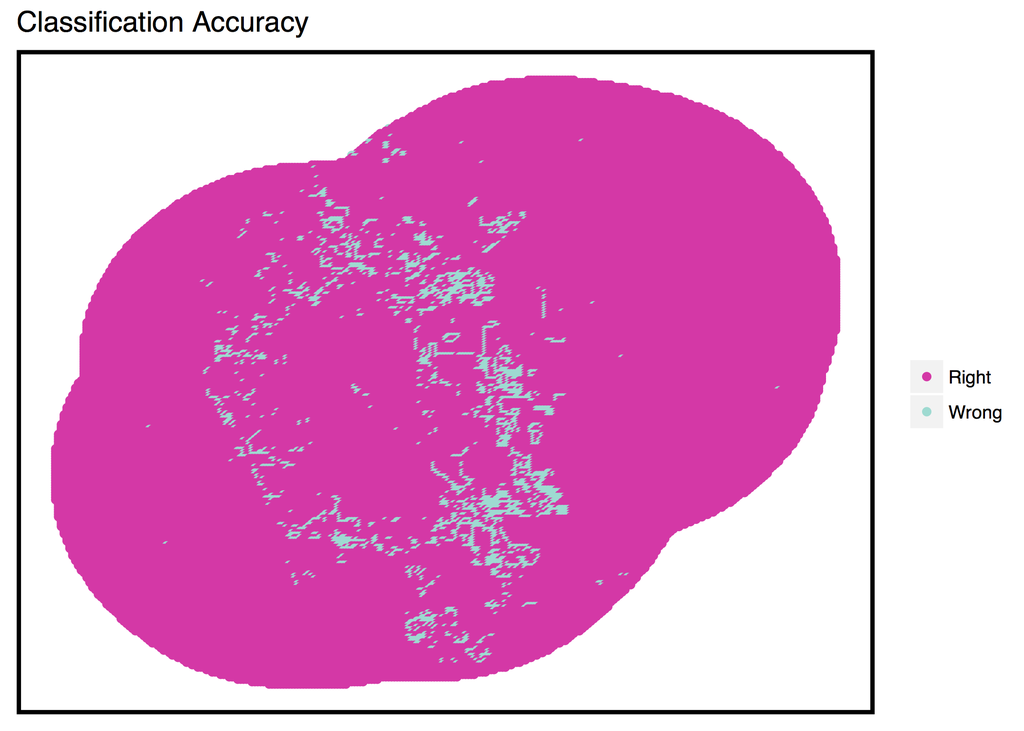

In general, we overpredicted development change. While only `1171` gridcells changed from undeveloped to developed between 2001 and 2011, we predicted that `2049` gridcells would undergo that change. This probably means our model is not capturing features that cause or inhibit development in the Denver metropolitan region. One feature we speculated could be zoning regulations, a feature that we did not have time to mine for importance for the whole metropolitan region of Devner. This model, while imperfect, still gives us a good vision of where development might occur, and could be used to predict future growth in the next decade.

### Development Contingency Planning

#### Demand-Side Change

We were tasked with predicting development growth in Denver given the growth of its population between 2010 and 2020. We first had to devise a method for predicting population growth in the metropolitan area between 2010 and 2020.

The US Census Bureau predicts that Denver proper will reach a population of 733,763 by the year 2020. We distributed that projected figure to all of the gridcells in the study area by dividing it by the number of gridcells. We then multiplied that figure by the population growth between 2000 and 2010. This gave us a good figure that simulated population growth in Denver. The code for this calculation, and others for 2020 population figures that were included in the model, can be seen below.

```r
denverPoints1$weightedPop2020 = (((733763/nrow(denverPoints1))* denverPoints1$pctPopChange)/100)

denverPoints1$weightedPop2020 = ifelse(denverPoints1$weightedPop2020 < 0, denverPoints1$weightedPop2010 - denverPoints1$weightedPop2020, denverPoints1$weightedPop2020)

denverPoints2 <- denverPoints1 %>%
  mutate(popChange2020 = weightedPop2020 - weightedPop2010,
       pctPopChange2020 = (popChange2020/weightedPop2010)*100) %>%
  mutate(weightedSLPop2020 = weightedSLPop2010*(((733763/nrow(denverPoints1))* denverPoints1$pctPopChange)/100)) %>%
  mutate(weightedSLPop2020 = ifelse(denverPoints2$weightedSLPop2020 < 0, denverPoints2$weightedPop2010 - denverPoints2$weightedSLPop2020, denverPoints2$weightedSLPop2020))

denverPoints2$pctPopChange2020[which(!is.finite(denverPoints2$pctPopChange2020))] <- 1
```

Once we created these new variables, we were able to replace the variables used in the model for predicting growth in 2011 to better reflect growth in 2020. This meant that any variable that was a 2000 variable was updated to 2010, and 2001 variables to 2011. This model can be seen below

```r
model5 <- glm(change0111 ~ popChange2020 + lc2011 + touching11 + transdist + devdist11 +
   airport + roaddist + weightedSLPop2020 + weightedSLPop2010 +
   pctPopChange2020, data=denverPoints2, family = binomial(link="logit"))
```

We were able to use this model to predict on Denver to see where development would occur in 2020. We recognize that this map is not perfect for many reasons, but at least the pattern looks similar to the 2011 predicted development of occuring on the edge of the already developed areas.

#### Figure 10

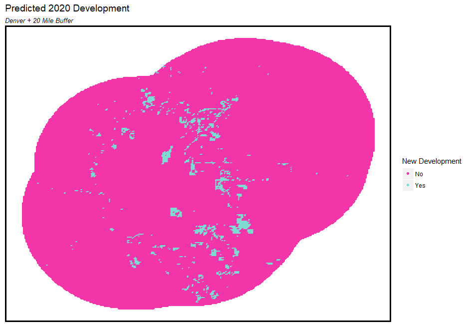

We wanted to make sure to not allocate development in areas that were sensitive. We were able to come up with a variable, `touching11`, that categorized gridcells as touching 2011 development or not. This also eliminated any of the sensitive areas, like water or wetlands, being developed.

First, we created a grouping data frame to show the population growth in areas where new development was predicted but not adjacent to development.

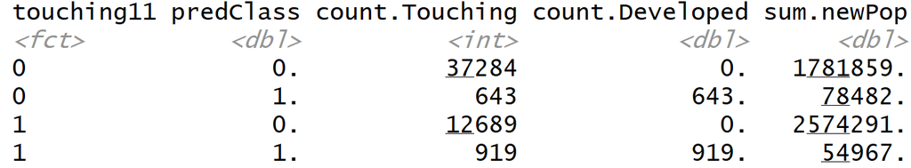

```r
growth_areas_good <- dat %>%
  filter(touching11 == 1 & predClass == 1) %>%
  dplyr::select(weightedPop2020,x,y, weightedPop2010) %>%
  mutate(percentOfGrowth = weightedPop2020/(sum(weightedPop2020))) %>%
  mutate(newPopulation = ((percentOfGrowth*78482.27)+weightedPop2020)) %>%
  mutate(newPopulationGrowth = ((newPopulation - weightedPop2010)/weightedPop2010)*100)
growth_areas_good$newPopulationGrowth[which(!is.finite(growth_areas_good$newPopulationGrowth))] <- 1
```

First, this math helped us generate a new prediction map where the allocation rules were accounted for, as seen in Figure 11:

#### Figure 11

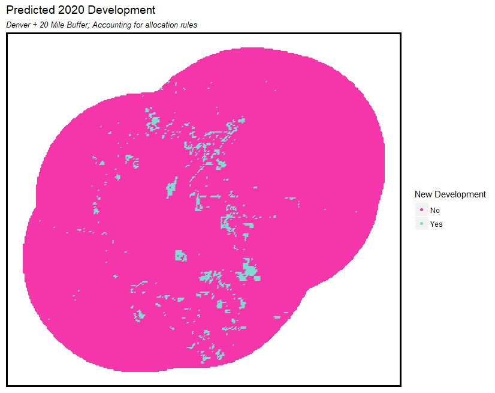

Then, using the same math, we looked at how population was distrubted across the metro area in the gridcells, seen in Figure 12:

#### Figure 12

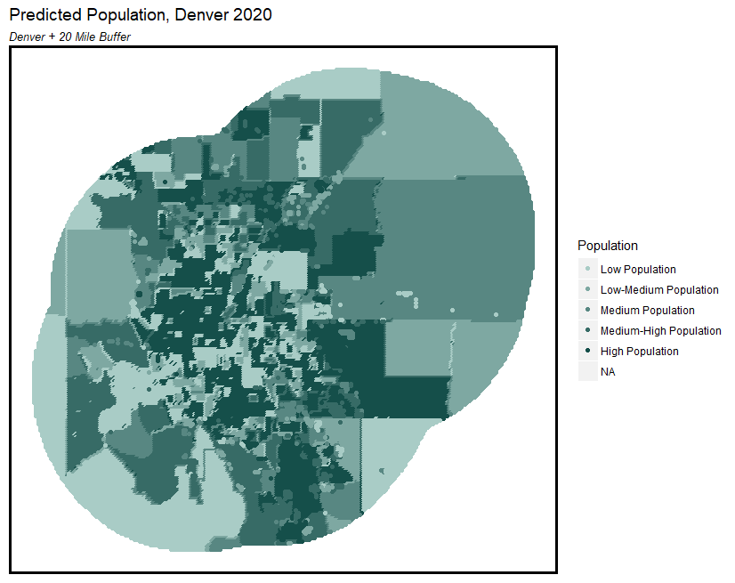

Lastly, we created a new growth map, which highlights how the metro area is changing and shows areas where there would be no predicted change because they did not meet the criteria to be developed in our allocation procedure.

#### Figure 13

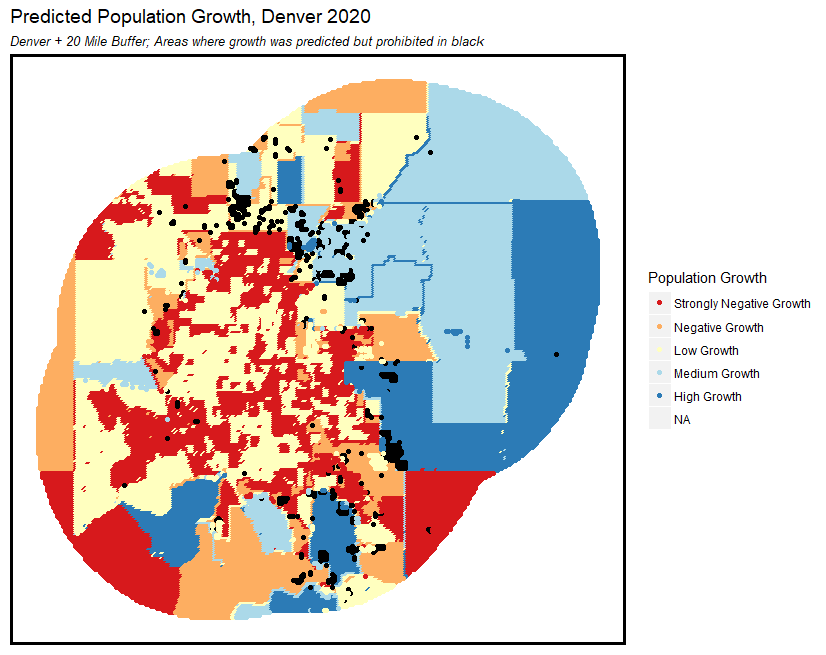

It is important to remember that these predictions are far from perfect and rely somewhat on inherited geometry from the census tract shapefiles used to create the data. However, it does give a good idea of where Denver’s metro would be predicted to grow the most using the model we devised and the restraints placed on development.

#### Supply-Side Change

The recent extensions of the lightrail in Denver have drawn massive amounts of new development. Because of this tremendous success, we felt it prudent to plan for future development around new stations. Specifically, we simulated the effect of a new line in southwest Denver on our 2020 development predictions. This area is currently not being serviced by the lightrail system, and is ripe for new development. The B line currently serves nearly 180,000 riders annually, so we expect demand for a new line to be high.

In order to predict the change in development based on this lightrail extension, we updated our model to include distance to the extension and current lightrail instead of only the current lightrail. Once we obtained the new predictions, we created a procedure to determine which areas we recommend you allocate for development, and which areas should be preserved. This procedure relied on three key criteria:

1. Is the cell located in a water body?
2. Is the cell predicted to develop?
3. Is the cell directly adjacent to a developed cell?

Using these criteria, we chose a conservative approach, only recommending a cell for development if it was not water, was predicted to develop, and was adjacent to development. Figure 14 compares the predicted development with the recommended development.

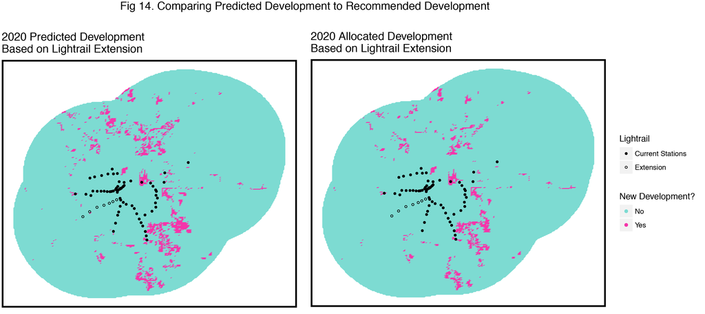

### Conclusion

We believe that using our 2020 predictions for development will aid DRCOG in its task of creating a comprehensive plan for Greater Denver. Our recommendations for allocation based on anticipated demand- and supply-side changes should inform DRCOG’s decision-making when preparing for these events. By referencing the forecasts and allocation procedures in this document, we are confident the DRCOG will be successful in moving forward with the planning process.